# **Análisis B2B**

### **Etapa 5: Análisis Exploratorio Detallado y Estacionalidad**

```
=================================================================
Prod: Gta. Club Extra Bs.x9 CR-PN (Cód: 97)
  Ventas: 435 | Fechas únicas: 435 | Rango: 2023-01-03 → 2025-11-29
  Precio mediano: 953 ML | Desc. prom.: 2.91%
```

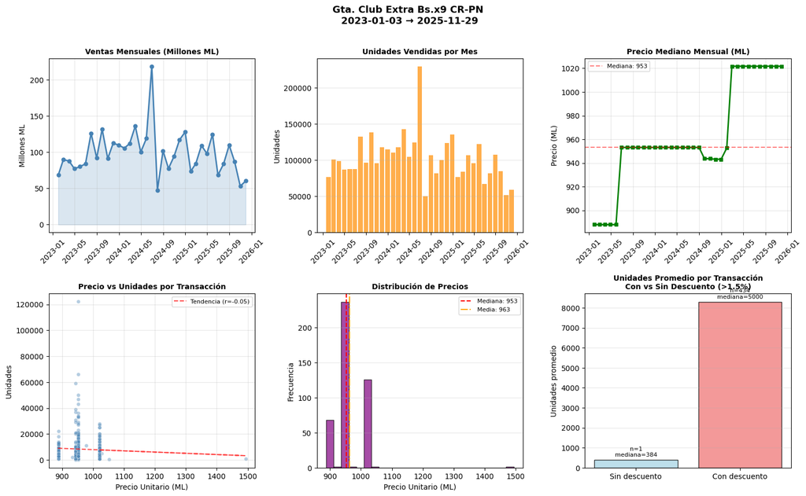

```
--> Sin quiebres detectados

=================================================================
Prod: Gta. Soda Pozuelo Ple. X 20 CRI CM (Cód: 157)
  Ventas: 487 | Fechas únicas: 487 | Rango: 2023-01-03 → 2025-11-28
  Precio mediano: 868 ML | Desc. prom.: 2.92%
```

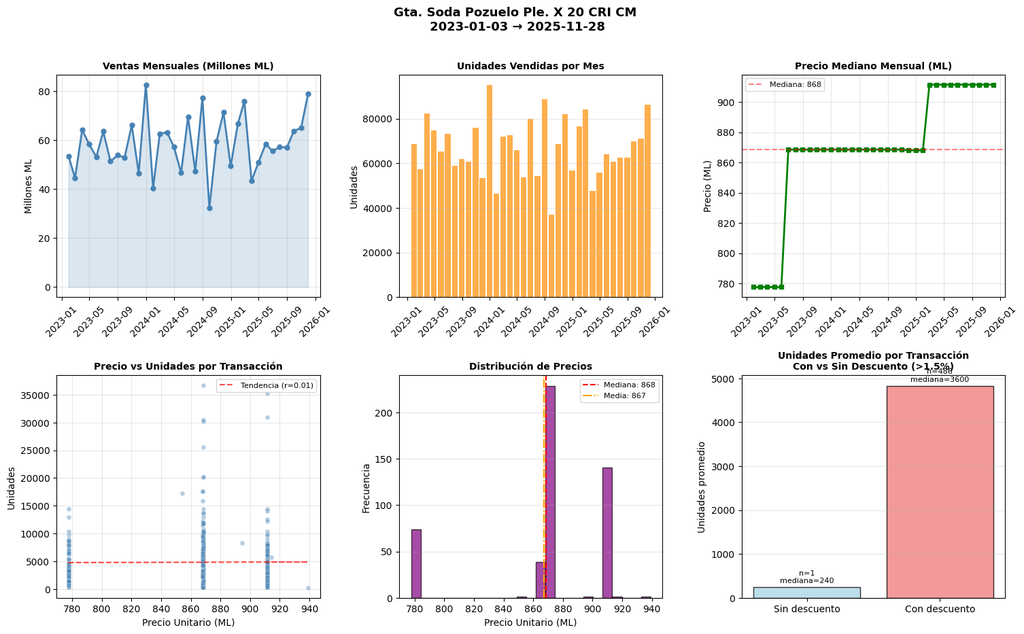

```
--> Sin quiebres detectados

=================================================================
Prod: Gta. Wafer Festival Nar. Bx12 C Mod (Cód: 123)
  Ventas: 456 | Fechas únicas: 456 | Rango: 2023-01-03 → 2025-11-29
  Precio mediano: 990 ML | Desc. prom.: 2.92%
```

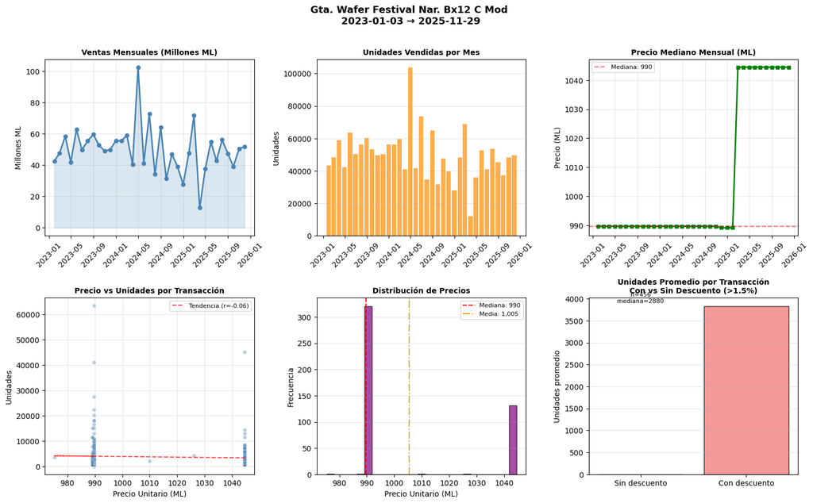

```
--> Sin quiebres detectados

=================================================================
Prod: Gta. Chiky Chocolate Bs. X 12 CRI (Cód: 481)
  Ventas: 318 | Fechas únicas: 318 | Rango: 2023-01-13 → 2025-11-28
  Precio mediano: 1,040 ML | Desc. prom.: 2.91%
```

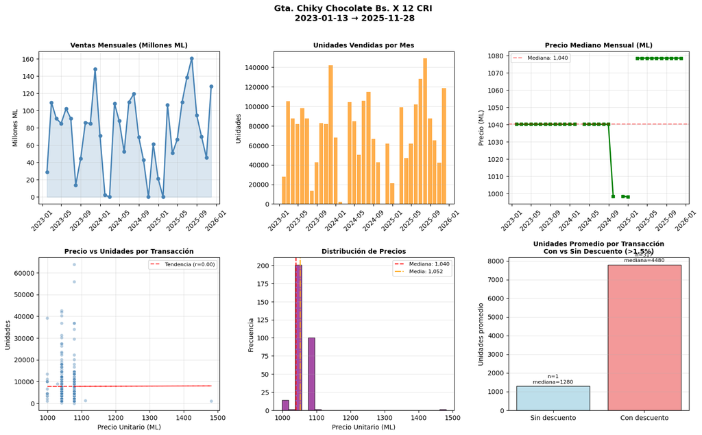

```
--> Posibles quiebres de stock: ['2024-02', '2024-10', '2025-01']

=================================================================
Prod: Gta. Mantequilla TentacionesBs.x12CRI NU (Cód: 127)
  Ventas: 398 | Fechas únicas: 398 | Rango: 2023-01-03 → 2025-11-29
  Precio mediano: 1,112 ML | Desc. prom.: 2.91%
```

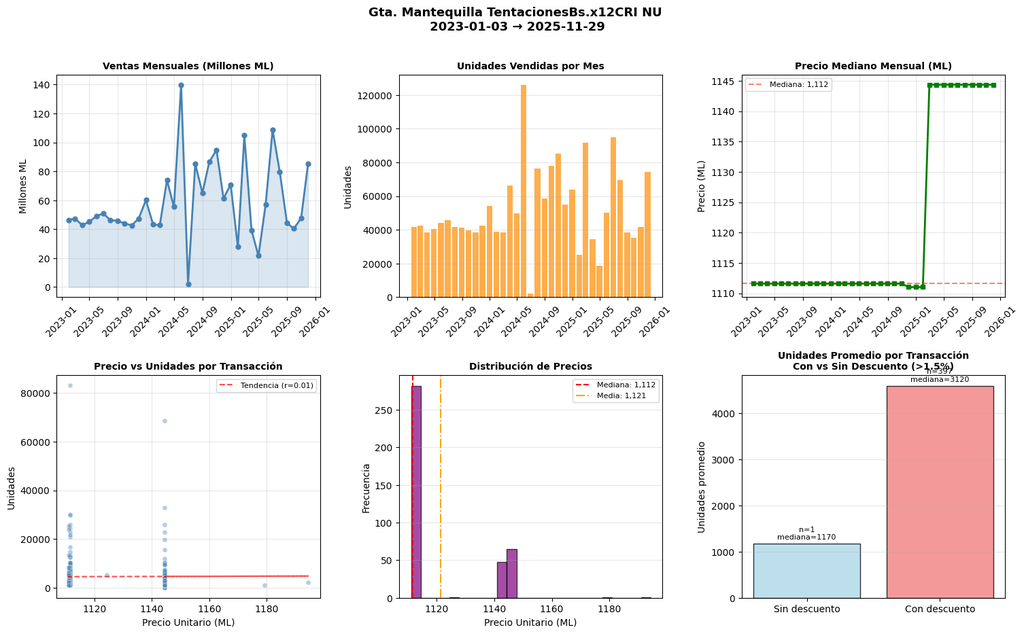

```
--> Sin quiebres detectados

=================================================================
Prod: Gta. Maria Pozuelo Bs. X 8 CRI NU 168 g (Cód: 135)
  Ventas: 457 | Fechas únicas: 457 | Rango: 2023-01-03 → 2025-11-29
  Precio mediano: 522 ML | Desc. prom.: 2.91%
```

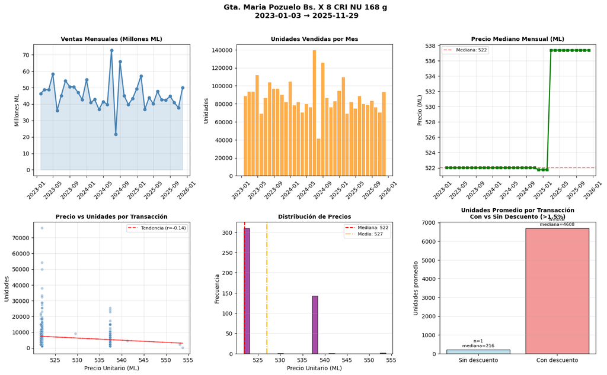

```
--> Sin quiebres detectados

=================================================================
Prod: Cocoa Dulce 400g 12x 400g CRI (Cód: 53)
  Ventas: 297 | Fechas únicas: 297 | Rango: 2023-01-03 → 2025-11-29
  Precio mediano: 969 ML | Desc. prom.: 2.92%
```

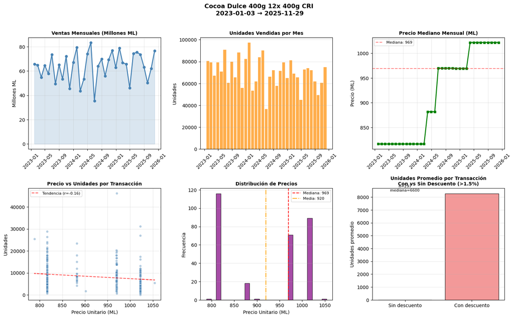

```
--> Sin quiebres detectados

=================================================================
Prod: Gta.SODA POZUELO Bsx15 330gr (Cód: 1085)
  Ventas: 326 | Fechas únicas: 326 | Rango: 2023-10-18 → 2025-11-28
  Precio mediano: 687 ML | Desc. prom.: 2.92%
```

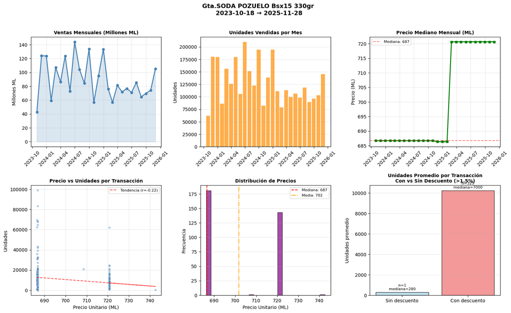

```
--> Sin quiebres detectados

=================================================================
Prod: Gta. Mantequilla Sabemas Bs. X 12 CRI WM (Cód: 37)
  Ventas: 349 | Fechas únicas: 349 | Rango: 2023-01-16 → 2025-11-29
  Precio mediano: 1,015 ML | Desc. prom.: 2.91%
```

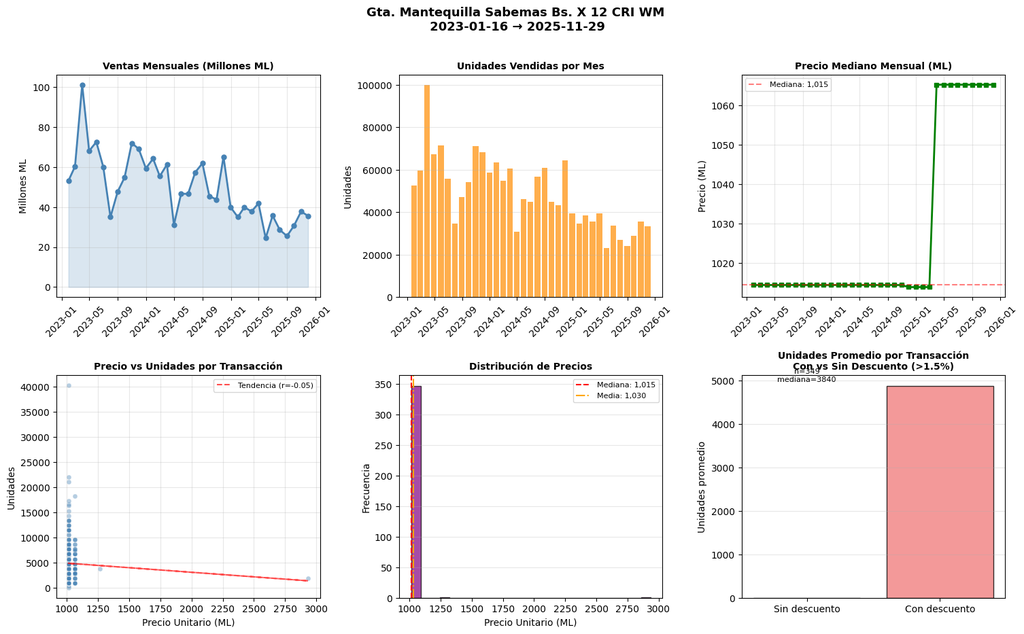

```
--> Sin quiebres detectados

=================================================================
Prod: GTA. YEMAS BS X6. CRI CM (Cód: 161)
  Ventas: 426 | Fechas únicas: 426 | Rango: 2023-01-03 → 2025-11-29
  Precio mediano: 785 ML | Desc. prom.: 2.91%
```

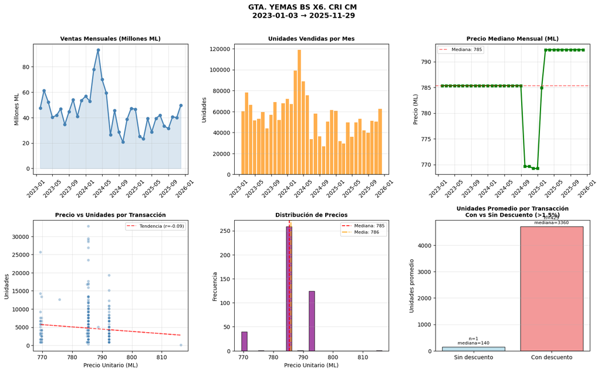

```
--> Sin quiebres detectados
```

```python
def visualizaciones(df_pv, desc):
    """
    Análisis exploratorio a nivel visual
    """

    print(f"\n{'='*65}") # Para dividir mejor los gráficos
    print(f"Prod: {desc} (Cód: {codigo})")
    print(f"  Ventas: {len(df_pv):,} | Fechas únicas: {df_pv['FECHA'].nunique():,} | "
          f"Rango: {df_pv['FECHA'].min().date()} → {df_pv['FECHA'].max().date()}")
    print(f"  Precio mediano: {df_pv['PRECIO_UNITARIO'].median():,.0f} ML | "
          f"Desc. prom.: {df_pv['PCT_DESCUENTO'].mean():.2f}%")
    fig = plt.figure(figsize=(18, 10))
    gs = fig.add_gridspec(2, 3, hspace=0.35, wspace=0.3)

    # Título principal
    fig.suptitle(f'{desc}\n {df_pv["FECHA"].min().date()} → {df_pv["FECHA"].max().date()}',
                 fontsize=13, fontweight='bold', y=0.98)

    # 1. Ventas ML mensuales
    ax1 = fig.add_subplot(gs[0, 0])
    mensual_ml = df_pv.set_index('FECHA').resample('ME')['VENTA_NETA_ML'].sum()
    ax1.plot(mensual_ml.index, mensual_ml.values / 1e6, 'o-', color='steelblue', lw=2, markersize=5)
    ax1.fill_between(mensual_ml.index, 0, mensual_ml.values / 1e6, alpha=0.2, color='steelblue')
    ax1.set_title('Ventas Mensuales (Millones ML)', fontsize=10, fontweight='bold')
    ax1.set_ylabel('Millones ML')
    ax1.grid(True, alpha=0.3)
    ax1.tick_params(axis='x', rotation=45)

    # 2. Unidades mensuales
    ax2 = fig.add_subplot(gs[0, 1])
    mensual_und = df_pv.set_index('FECHA').resample('ME')['VENTA_NETA_UNIDADES'].sum()
    ax2.bar(mensual_und.index, mensual_und.values, color='darkorange', alpha=0.7, width=25)
    ax2.set_title('Unidades Vendidas por Mes', fontsize=10, fontweight='bold')
    ax2.set_ylabel('Unidades')
    ax2.grid(True, alpha=0.3, axis='y')
    ax2.tick_params(axis='x', rotation=45)

    # 3. Precio mediano mensual
    ax3 = fig.add_subplot(gs[0, 2])
    mensual_precio = df_pv.set_index('FECHA').resample('ME')['PRECIO_UNITARIO'].median()
    ax3.plot(mensual_precio.index, mensual_precio.values, 's-', color='green', lw=2, markersize=5)
    ax3.axhline(y=df_pv['PRECIO_UNITARIO'].median(), color='red', linestyle='--', alpha=0.5,
                label=f'Mediana: {df_pv["PRECIO_UNITARIO"].median():,.0f}')
    ax3.set_title('Precio Mediano Mensual (ML)', fontsize=10, fontweight='bold')
    ax3.set_ylabel('Precio (ML)')
    ax3.legend(fontsize=8)
    ax3.grid(True, alpha=0.3)
    ax3.tick_params(axis='x', rotation=45)

    # 4. Scatter precio vs unidades (con línea de tendencia)
    ax4 = fig.add_subplot(gs[1, 0])
    mask = (df_pv['PRECIO_UNITARIO'] > 0) & (df_pv['VENTA_NETA_UNIDADES'] > 0)

    ax4.scatter(df_pv.loc[mask, 'PRECIO_UNITARIO'],
                df_pv.loc[mask, 'VENTA_NETA_UNIDADES'],
                alpha=0.4, c='steelblue', s=25, edgecolors='white', linewidth=0.5)

    # Línea de tendencia
    from scipy import stats
    x = df_pv.loc[mask, 'PRECIO_UNITARIO'].values
    y = df_pv.loc[mask, 'VENTA_NETA_UNIDADES'].values
    if len(x) > 5:
        slope, intercept, r_value, p_value, std_err = stats.linregress(x, y)
        ax4.plot(x, intercept + slope * x, 'r--', alpha=0.7, lw=1.5,
                label=f'Tendencia (r={r_value:.2f})')

    ax4.set_title('Precio vs Unidades por Transacción', fontsize=10, fontweight='bold')
    ax4.set_xlabel('Precio Unitario (ML)')
    ax4.set_ylabel('Unidades')
    ax4.legend(fontsize=8)
    ax4.grid(True, alpha=0.3)

    # 5. Distribución de precios (reemplaza box plot)
    ax5 = fig.add_subplot(gs[1, 1])
    ax5.hist(df_pv['PRECIO_UNITARIO'].dropna(), bins=25, color='purple', alpha=0.7, edgecolor='black')
    ax5.axvline(df_pv['PRECIO_UNITARIO'].median(), color='red', linestyle='--',
                label=f'Mediana: {df_pv["PRECIO_UNITARIO"].median():,.0f}')
    ax5.axvline(df_pv['PRECIO_UNITARIO'].mean(), color='orange', linestyle='-.',
                label=f'Media: {df_pv["PRECIO_UNITARIO"].mean():,.0f}')
    ax5.set_title('Distribución de Precios', fontsize=10, fontweight='bold')
    ax5.set_xlabel('Precio Unitario (ML)')
    ax5.set_ylabel('Frecuencia')
    ax5.legend(fontsize=8)
    ax5.grid(True, alpha=0.3, axis='y')

    # 6. Comparación de volumen con/sin descuento (reemplaza heatmap)
    ax6 = fig.add_subplot(gs[1, 2])

    # Identificar transacciones con descuento significativo (>1.5%)
    df_pv['DESCUENTO_SIGNIFICATIVO'] = df_pv['PCT_DESCUENTO'] > 1.5

    # Calcular volumen promedio por tipo
    stats_dto = df_pv.groupby('DESCUENTO_SIGNIFICATIVO').agg(
        count=('VENTA_NETA_UNIDADES', 'count'),
        unidades_prom=('VENTA_NETA_UNIDADES', 'mean'),
        unidades_med=('VENTA_NETA_UNIDADES', 'median'),
        ventas_prom=('VENTA_NETA_ML', 'mean')
    ).round(0)

    # Gráfico de barras
    categorias = ['Sin descuento', 'Con descuento']
    valores = [stats_dto.loc[False, 'unidades_prom'] if False in stats_dto.index else 0,
               stats_dto.loc[True, 'unidades_prom'] if True in stats_dto.index else 0]
    colores_bar = ['lightblue', 'lightcoral']

    bars = ax6.bar(categorias, valores, color=colores_bar, edgecolor='black', alpha=0.8)

    # Añadir etiquetas con n y mediana
    for i, (idx, row) in enumerate(stats_dto.iterrows()):
        label = f'n={int(row["count"])}\nmediana={int(row["unidades_med"])}'
        ax6.text(i, row['unidades_prom'] + max(valores)*0.02, label, ha='center', fontsize=8)

    ax6.set_title('Unidades Promedio por Transacción\nCon vs Sin Descuento (>1.5%)', fontsize=10, fontweight='bold')
    ax6.set_ylabel('Unidades promedio')
    ax6.grid(True, alpha=0.3, axis='y')

    plt.tight_layout()
    plt.show()

    # Detectar quiebres
    mensual_und_check = df_pv.set_index('FECHA').resample('ME')['VENTA_NETA_UNIDADES'].sum()
    quiebres = [str(idx.date())[:7] for idx, v in mensual_und_check.items() if v == 0]

    return quiebres
for codigo in productos_seleccionados:
    df_p = df_ventas_enriquecido[df_ventas_enriquecido['CODIGO_MATERIAL'] == codigo].copy()
    df_pv = df_p[df_p['TIPO_TRANSACCION'] == 'VENTA'].copy()

    desc = df_pv['DESCRIPCION_MATERIAL'].iloc[0] if len(df_pv) else f"Código {codigo}"

    quiebres = visualizaciones(df_pv, desc)

    if quiebres:
        print(f"--> Posibles quiebres de stock: {quiebres}")
    else:
        print(f"--> Sin quiebres detectados")
```

#### **Análisis de estacionalidad**

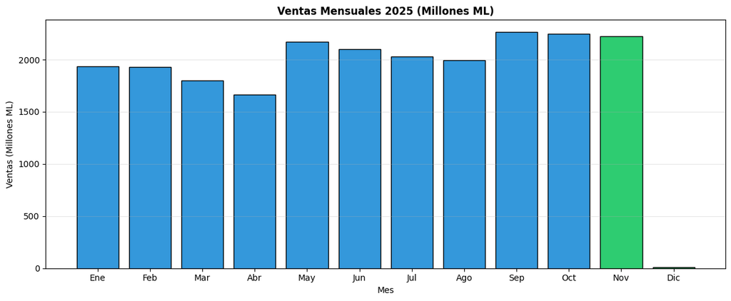

```python
ventas_mensuales_2025 = df_2025.groupby(df_2025['FECHA'].dt.month)['VENTA_NETA_ML'].sum()
meses = ['Ene', 'Feb', 'Mar', 'Abr', 'May', 'Jun', 'Jul', 'Ago', 'Sep', 'Oct', 'Nov', 'Dic']

fig, ax = plt.subplots(figsize=(12, 5))
meses_disp = [m for i, m in enumerate(meses, 1) if i in ventas_mensuales_2025.index]
ventas_disp = [ventas_mensuales_2025[i] / 1e6 for i in range(1, 13) if i in ventas_mensuales_2025.index]

colors = ['#2ecc71' if m in ['Nov', 'Dic'] else '#3498db' for m in meses_disp]
ax.bar(meses_disp, ventas_disp, color=colors, edgecolor='black')
ax.set_title('Ventas Mensuales 2025 (Millones ML)', fontsize=12, fontweight='bold')
ax.set_xlabel('Mes')
ax.set_ylabel('Ventas (Millones ML)')
ax.grid(True, alpha=0.3, axis='y')
plt.tight_layout()
plt.show()
```

### **Etapa 6: Modelado de Elasticidad y Respuesta al Precio**

```python
resultados_elasticidad = []

for codigo in productos_seleccionados:
    # Filtrar datos del producto
    df_p = df_ventas_enriquecido[
        (df_ventas_enriquecido['CODIGO_MATERIAL'] == codigo) &
        (df_ventas_enriquecido['TIPO_TRANSACCION'] == 'VENTA') &
        (df_ventas_enriquecido['VENTA_NETA_UNIDADES'] > 0) &
        (df_ventas_enriquecido['PRECIO_UNITARIO'] > 0)
    ].copy()

    # Obtener descripción
    if len(df_p) > 0 and pd.notnull(df_p['DESCRIPCION_MATERIAL'].iloc[0]):
        desc = str(df_p['DESCRIPCION_MATERIAL'].iloc[0])[:50]
    else:
        desc = f"Codigo {codigo}"

    # Agrupacion mensual - CORREGIDO: usar groupby con año y mes
    df_p['ANO_MES'] = df_p['FECHA'].dt.to_period('M')

    mensual = df_p.groupby('ANO_MES').agg(
        unidades=('VENTA_NETA_UNIDADES', 'sum'),
        precio=('PRECIO_UNITARIO', 'median'),
        mes=('MES', 'first'),
        anio=('AÑO', 'first'),
    ).reset_index()

    # Eliminar columna ANO_MES (ya no la necesitamos)
    if 'ANO_MES' in mensual.columns:
        mensual = mensual.drop(columns=['ANO_MES'])

    # Verificar cantidad de meses
    if len(mensual) < 12:
        print(f"  [{codigo}] {desc[:35]:<35} -> OMITIDO: solo {len(mensual)} meses (minimo 12)")
        resultados_elasticidad.append({
            'CODIGO_MATERIAL': codigo,
            'descripcion': desc,
            'elasticidad': None,
            'r2': None,
            'p_valor': None,
            'n_obs': len(mensual),
            'precio_mediano': mensual['precio'].median() if len(mensual) > 0 else None,
            'nota': f'insuficiente: {len(mensual)} meses'
        })
        continue

    # Transformaciones logaritmicas
    mensual['log_u'] = np.log(mensual['unidades'].replace(0, np.nan))
    mensual['log_p'] = np.log(mensual['precio'].replace(0, np.nan))
    mensual['mes_s'] = mensual['mes'].astype(str)
    mensual['anio_s'] = mensual['anio'].astype(str)

    # Eliminar filas con valores nulos
    mensual_clean = mensual.dropna(subset=['log_u', 'log_p']).copy()

    if len(mensual_clean) < 12:
        print(f"  [{codigo}] {desc[:35]:<35} -> OMITIDO: solo {len(mensual_clean)} obs validas tras log")
        resultados_elasticidad.append({
            'CODIGO_MATERIAL': codigo,
            'descripcion': desc,
            'elasticidad': None,
            'r2': None,
            'p_valor': None,
            'n_obs': len(mensual_clean),
            'precio_mediano': mensual['precio'].median(),
            'nota': f'insuficiente tras log: {len(mensual_clean)} obs'
        })
        continue

    # Construir formula del modelo
    n_meses = mensual_clean['mes_s'].nunique()
    n_anios = mensual_clean['anio_s'].nunique()

    if n_meses > 1 and n_anios > 1:
        formula = 'log_u ~ log_p + C(mes_s) + C(anio_s)'
    elif n_meses > 1:
        formula = 'log_u ~ log_p + C(mes_s)'
    else:
        formula = 'log_u ~ log_p'

    # Ajustar modelo
    try:
        modelo = smf.ols(formula=formula, data=mensual_clean).fit()

        elasticidad = modelo.params.get('log_p', None)
        r2 = modelo.rsquared
        p_valor = modelo.pvalues.get('log_p', None)
        precio_med = mensual_clean['precio'].median()

        # Determinar significancia
        if p_valor is not None and p_valor < 0.05:
            sig_symbol = "SIGNIFICATIVO"
        else:
            sig_symbol = "NO significativo"

        print(f"  [{codigo}] {sig_symbol} | {desc[:35]:<35} | "
              f"e={elasticidad:+.3f} | R²={r2:.3f} | p={p_valor:.4f} | n={len(mensual_clean)}")

        resultados_elasticidad.append({
            'CODIGO_MATERIAL': codigo,
            'descripcion': desc,
            'elasticidad': elasticidad,
            'r2': r2,
            'p_valor': p_valor,
            'n_obs': len(mensual_clean),
            'precio_mediano': precio_med,
            'nota': 'ok'
        })

    except Exception as e:
        print(f"  [{codigo}] ERROR: {str(e)[:80]}")
        resultados_elasticidad.append({
            'CODIGO_MATERIAL': codigo,
            'descripcion': desc,
            'elasticidad': None,
            'r2': None,
            'p_valor': None,
            'n_obs': len(mensual_clean),
            'precio_mediano': mensual_clean['precio'].median() if len(mensual_clean) > 0 else None,
            'nota': f'error: {str(e)[:40]}'
        })

# Crear dataframe de resultados
df_elasticidad = pd.DataFrame(resultados_elasticidad)

df_ok = df_elasticidad[df_elasticidad['nota'] == 'ok'].copy()

if len(df_ok) > 0:
    print("\nModelos exitosos:")
    for _, row in df_ok.iterrows():
        e = row['elasticidad']
        if e is not None:
            if abs(e) > 1:
                tipo = "elastico (sensible a precio)"
                interpretacion = f"subir precio 1% reduce ventas {abs(e):.1f}%"
            else:
                tipo = "inelastico (poco sensible a precio)"
                interpretacion = f"subir precio 1% reduce ventas {abs(e):.1f}%"

            print(f"\n  Producto: {row['descripcion'][:45]}")
            print(f"    Elasticidad: {e:+.3f} -> demanda {tipo}")
            print(f"    {interpretacion}")
            print(f"    R²: {row['r2']:.3f} | p-valor: {row['p_valor']:.4f}")
else:
    print("\n  No se obtuvieron modelos validos")

# Mostrar productos omitidos
df_omitidos = df_elasticidad[df_elasticidad['nota'] != 'ok']
if len(df_omitidos) > 0:
    print(f"\nProductos omitidos: {len(df_omitidos)}")
    for _, row in df_omitidos.iterrows():
        print(f"  - {row['descripcion'][:40]} : {row['nota']}")
```

```
  [97] NO significativo | Gta. Club Extra Bs.x9 CR-PN         | e=+4.084 | R²=0.422 | p=0.1446 | n=35
  [157] NO significativo | Gta. Soda Pozuelo Ple. X 20 CRI CM  | e=-1.244 | R²=0.273 | p=0.4109 | n=35
  [123] NO significativo | Gta. Wafer Festival Nar. Bx12 C Mod | e=-3.592 | R²=0.349 | p=0.6787 | n=35
  [481] NO significativo | Gta. Chiky Chocolate Bs. X 12 CRI   | e=+16.011 | R²=0.612 | p=0.2916 | n=32
  [127] NO significativo | Gta. Mantequilla TentacionesBs.x12C | e=+19.763 | R²=0.247 | p=0.5496 | n=35
  [135] NO significativo | Gta. Maria Pozuelo Bs. X 8 CRI NU 1 | e=-12.222 | R²=0.392 | p=0.1949 | n=35
  [53] NO significativo | Cocoa Dulce 400g 12x 400g CRI       | e=-1.107 | R²=0.345 | p=0.3898 | n=35
  [1085] NO significativo | Gta.SODA POZUELO Bsx15 330gr        | e=-11.224 | R²=0.724 | p=0.1734 | n=26
  [37] NO significativo | Gta. Mantequilla Sabemas Bs. X 12 C | e=-2.510 | R²=0.741 | p=0.5803 | n=35
  [161] SIGNIFICATIVO | GTA. YEMAS BS X6. CRI CM            | e=+27.038 | R²=0.555 | p=0.0158 | n=35

Modelos exitosos:

  Producto: Gta. Club Extra Bs.x9 CR-PN
    Elasticidad: +4.084 -> demanda elastico (sensible a precio)
    subir precio 1% reduce ventas 4.1%
    R²: 0.422 | p-valor: 0.1446

  Producto: Gta. Soda Pozuelo Ple. X 20 CRI CM
    Elasticidad: -1.244 -> demanda elastico (sensible a precio)
    subir precio 1% reduce ventas 1.2%
    R²: 0.273 | p-valor: 0.4109

  Producto: Gta. Wafer Festival Nar. Bx12 C Mod
    Elasticidad: -3.592 -> demanda elastico (sensible a precio)
    subir precio 1% reduce ventas 3.6%
    R²: 0.349 | p-valor: 0.6787

  Producto: Gta. Chiky Chocolate Bs. X 12 CRI
    Elasticidad: +16.011 -> demanda elastico (sensible a precio)
    subir precio 1% reduce ventas 16.0%
    R²: 0.612 | p-valor: 0.2916

  Producto: Gta. Mantequilla TentacionesBs.x12CRI NU
    Elasticidad: +19.763 -> demanda elastico (sensible a precio)
    subir precio 1% reduce ventas 19.8%
    R²: 0.247 | p-valor: 0.5496

  Producto: Gta. Maria Pozuelo Bs. X 8 CRI NU 168 g
    Elasticidad: -12.222 -> demanda elastico (sensible a precio)
    subir precio 1% reduce ventas 12.2%
    R²: 0.392 | p-valor: 0.1949

  Producto: Cocoa Dulce 400g 12x 400g CRI
    Elasticidad: -1.107 -> demanda elastico (sensible a precio)
    subir precio 1% reduce ventas 1.1%
    R²: 0.345 | p-valor: 0.3898

  Producto: Gta.SODA POZUELO Bsx15 330gr
    Elasticidad: -11.224 -> demanda elastico (sensible a precio)
    subir precio 1% reduce ventas 11.2%
    R²: 0.724 | p-valor: 0.1734

  Producto: Gta. Mantequilla Sabemas Bs. X 12 CRI WM
    Elasticidad: -2.510 -> demanda elastico (sensible a precio)
    subir precio 1% reduce ventas 2.5%
    R²: 0.741 | p-valor: 0.5803

  Producto: GTA. YEMAS BS X6. CRI CM
    Elasticidad: +27.038 -> demanda elastico (sensible a precio)
    subir precio 1% reduce ventas 27.0%
    R²: 0.555 | p-valor: 0.0158
```

#### **Los resultados no son determinantes se hará un ajuste**

```python
resultados_elasticidad = []

for codigo in productos_seleccionados:
    # Filtrar datos del producto
    df_p = df_ventas_enriquecido[
        (df_ventas_enriquecido['CODIGO_MATERIAL'] == codigo) &
        (df_ventas_enriquecido['TIPO_TRANSACCION'] == 'VENTA') &
        (df_ventas_enriquecido['VENTA_NETA_UNIDADES'] > 0) &
        (df_ventas_enriquecido['PRECIO_UNITARIO'] > 0)
    ].copy()

    # Obtener descripcion
    if len(df_p) > 0 and pd.notnull(df_p['DESCRIPCION_MATERIAL'].iloc[0]):
        desc = str(df_p['DESCRIPCION_MATERIAL'].iloc[0])[:50]
    else:
        desc = f"Codigo {codigo}"

    # Calcular coeficiente de variacion del precio
    cv_precio = df_p['PRECIO_UNITARIO'].std() / df_p['PRECIO_UNITARIO'].mean()

    # Verificar variabilidad minima
    if cv_precio < 0.03:
        print(f"  [{codigo}] {desc[:35]:<35} -> OMITIDO: poca variabilidad de precio (CV={cv_precio:.4f})")
        resultados_elasticidad.append({
            'CODIGO_MATERIAL': codigo,
            'descripcion': desc,
            'elasticidad': None,
            'r2': None,
            'p_valor': None,
            'n_obs': 0,
            'precio_mediano': df_p['PRECIO_UNITARIO'].median(),
            'cv_precio': cv_precio,
            'nota': f'baja variabilidad (CV={cv_precio:.4f})'
        })
        continue

    # Agregacion mensual
    df_p['ANO_MES'] = df_p['FECHA'].dt.to_period('M')

    mensual = df_p.groupby('ANO_MES').agg(
        unidades=('VENTA_NETA_UNIDADES', 'sum'),
        precio=('PRECIO_UNITARIO', 'median'),
        mes=('MES', 'first'),
        anio=('AÑO', 'first'),
    ).reset_index()

    if 'ANO_MES' in mensual.columns:
        mensual = mensual.drop(columns=['ANO_MES'])

    if len(mensual) < 12:
        print(f"  [{codigo}] {desc[:35]:<35} -> OMITIDO: solo {len(mensual)} meses")
        resultados_elasticidad.append({
            'CODIGO_MATERIAL': codigo,
            'descripcion': desc,
            'elasticidad': None,
            'r2': None,
            'p_valor': None,
            'n_obs': len(mensual),
            'precio_mediano': mensual['precio'].median() if len(mensual) > 0 else None,
            'cv_precio': cv_precio,
            'nota': f'insuficiente: {len(mensual)} meses'
        })
        continue

    # Transformaciones
    mensual['log_u'] = np.log(mensual['unidades'].replace(0, np.nan))
    mensual['log_p'] = np.log(mensual['precio'].replace(0, np.nan))
    mensual['mes_s'] = mensual['mes'].astype(str)
    mensual['anio_s'] = mensual['anio'].astype(str)

    mensual_clean = mensual.dropna(subset=['log_u', 'log_p']).copy()

    if len(mensual_clean) < 12:
        print(f"  [{codigo}] {desc[:35]:<35} -> OMITIDO: {len(mensual_clean)} obs tras log")
        resultados_elasticidad.append({
            'CODIGO_MATERIAL': codigo,
            'descripcion': desc,
            'elasticidad': None,
            'r2': None,
            'p_valor': None,
            'n_obs': len(mensual_clean),
            'precio_mediano': mensual['precio'].median(),
            'cv_precio': cv_precio,
            'nota': f'insuficiente tras log: {len(mensual_clean)} obs'
        })
        continue

    # Construir formula
    n_meses = mensual_clean['mes_s'].nunique()
    n_anios = mensual_clean['anio_s'].nunique()

    if n_meses > 1 and n_anios > 1:
        formula = 'log_u ~ log_p + C(mes_s) + C(anio_s)'
    elif n_meses > 1:
        formula = 'log_u ~ log_p + C(mes_s)'
    else:
        formula = 'log_u ~ log_p'

    # Ajustar modelo
    try:
        modelo = smf.ols(formula=formula, data=mensual_clean).fit()

        elasticidad = modelo.params.get('log_p', None)
        r2 = modelo.rsquared
        p_valor = modelo.pvalues.get('log_p', None)

        # Verificar signo economico (elasticidad negativa para bienes normales)
        signo_correcto = elasticidad < 0 if elasticidad is not None else False

        if elasticidad is not None and p_valor is not None:
            if p_valor < 0.05 and signo_correcto:
                sig_symbol = "SIGNIFICATIVO"
            elif p_valor < 0.05 and not signo_correcto:
                sig_symbol = "SIGNIFICATIVO PERO SIGNO INCORRECTO"
            else:
                sig_symbol = "NO SIGNIFICATIVO"

            print(f"  [{codigo}] {sig_symbol} | {desc[:35]:<35} | "
                  f"e={elasticidad:+.3f} | R²={r2:.3f} | p={p_valor:.4f} | CV={cv_precio:.4f}")

        resultados_elasticidad.append({
            'CODIGO_MATERIAL': codigo,
            'descripcion': desc,
            'elasticidad': elasticidad,
            'r2': r2,
            'p_valor': p_valor,
            'n_obs': len(mensual_clean),
            'precio_mediano': mensual_clean['precio'].median(),
            'cv_precio': cv_precio,
            'signo_correcto': signo_correcto,
            'nota': 'ok' if (p_valor < 0.05 and signo_correcto) else 'no significativo o signo incorrecto'
        })

    except Exception as e:
        print(f"  [{codigo}] ERROR: {str(e)[:80]}")
        resultados_elasticidad.append({
            'CODIGO_MATERIAL': codigo,
            'descripcion': desc,
            'elasticidad': None,
            'r2': None,
            'p_valor': None,
            'n_obs': len(mensual_clean),
            'precio_mediano': mensual_clean['precio'].median() if len(mensual_clean) > 0 else None,
            'cv_precio': cv_precio,
            'signo_correcto': False,
            'nota': f'error: {str(e)[:40]}'
        })

df_elasticidad = pd.DataFrame(resultados_elasticidad)

df_ok = df_elasticidad[(df_elasticidad['nota'] == 'ok')].copy()
```

```
  [97] NO SIGNIFICATIVO | Gta. Club Extra Bs.x9 CR-PN         | e=+4.084 | R²=0.422 | p=0.1446 | CV=0.0533
  [157] NO SIGNIFICATIVO | Gta. Soda Pozuelo Ple. X 20 CRI CM  | e=-1.244 | R²=0.273 | p=0.4109 | CV=0.0490
  [123] Gta. Wafer Festival Nar. Bx12 C Mod -> OMITIDO: poca variabilidad de precio (CV=0.0248)
  [481] NO SIGNIFICATIVO | Gta. Chiky Chocolate Bs. X 12 CRI   | e=+16.011 | R²=0.612 | p=0.2916 | CV=0.0305
  [127] Gta. Mantequilla TentacionesBs.x12C -> OMITIDO: poca variabilidad de precio (CV=0.0138)
  [135] Gta. Maria Pozuelo Bs. X 8 CRI NU 1 -> OMITIDO: poca variabilidad de precio (CV=0.0140)
  [53] NO SIGNIFICATIVO | Cocoa Dulce 400g 12x 400g CRI       | e=-1.107 | R²=0.345 | p=0.3898 | CV=0.0981
  [1085] Gta.SODA POZUELO Bsx15 330gr        -> OMITIDO: poca variabilidad de precio (CV=0.0243)
  [37] NO SIGNIFICATIVO | Gta. Mantequilla Sabemas Bs. X 12 C | e=-2.510 | R²=0.741 | p=0.5803 | CV=0.1019
  [161] GTA. YEMAS BS X6. CRI CM            -> OMITIDO: poca variabilidad de precio (CV=0.0081)
```

### ES **Hallazgo**

No se obtuvo modelos economicamente validos. Esto sugiere que con dicha información no se puede estimar elasticidad de forma confiable

Posibles razones:

1. El precio de Retail a Wmrt no varia lo suficiente
2. La relacion precio-demanda es no lineal
3. Hay factores no observados (promociones, competencia)

**¿Qué significa?**

[output not shown]

### US **Finding**

No economically valid models were obtained. This suggests that elasticity cannot be reliably estimated with this information.

Possible reasons:

1. Retail's price to Wlmrt does not vary sufficiently.
2. The price-demand relationship is nonlinear.
3. There are unobserved factors (promotions, competition).

**What does this mean?**

[output not shown]

**Conclusion:** The current pricing policy does not allow for measuring the impact of price changes.

#### **Evaluación del Descuento del 3 %**

```python
df_p = df_ventas_enriquecido[df_ventas_enriquecido['TIPO_TRANSACCION'] == 'VENTA'].copy()

# Crear categorias de descuento
df_p['rango_descuento'] = pd.cut(df_p['PCT_DESCUENTO'],
                                  bins=[-1, 0.5, 2.5, 3.5, 5, 100],
                                  labels=['Sin descuento', '0-2.5%', '2.5-3.5%', '3.5-5%', '>5%'])

resumen_dto = df_p.groupby('rango_descuento').agg(
    transacciones=('VENTA_NETA_UNIDADES', 'count'),
    unidades_prom=('VENTA_NETA_UNIDADES', 'mean'),
    ventas_prom=('VENTA_NETA_ML', 'mean')
).round(0)

print("\nComparacion por rango de descuento:")
print(resumen_dto.to_string())

# Verificar si hay diferencia significativa entre 3% y otros rangos
dto_3pct = df_p[(df_p['PCT_DESCUENTO'] >= 2.5) & (df_p['PCT_DESCUENTO'] <= 3.5)]
dto_0 = df_p[df_p['PCT_DESCUENTO'] <= 0.5]

if len(dto_3pct) > 0 and len(dto_0) > 0:
    from scipy import stats
    t_stat, p_valor = stats.ttest_ind(dto_3pct['VENTA_NETA_UNIDADES'],
                                       dto_0['VENTA_NETA_UNIDADES'])

    print(f"\nPrueba t-test: Descuento ~3% vs Sin descuento")
    print(f"  Unidades promedio con descuento 3%: {dto_3pct['VENTA_NETA_UNIDADES'].mean():.0f}")
    print(f"  Unidades promedio sin descuento: {dto_0['VENTA_NETA_UNIDADES'].mean():.0f}")
    print(f"  p-valor: {p_valor:.4f}")

    if p_valor < 0.05:
        print("  Conclusion: Diferencia estadisticamente significativa")
        if dto_3pct['VENTA_NETA_UNIDADES'].mean() > dto_0['VENTA_NETA_UNIDADES'].mean():
            print("  El descuento del 3% se asocia con MAYOR volumen por transaccion")
        else:
            print("  El descuento del 3% se asocia con MENOR volumen por transaccion")
    else:
        print("  Conclusion: No hay diferencia estadisticamente significativa")
        print("  El descuento del 3% no parece afectar el volumen de compra")
```

```
Comparacion por rango de descuento:
                 transacciones  unidades_prom  ventas_prom
rango_descuento
Sin descuento             1124         153.00    198683.00
0-2.5%                       0            NaN          NaN
2.5-3.5%                 64306        1849.00   1120341.00
3.5-5%                     129         222.00    327937.00
>5%                       2174          60.00    133542.00

Prueba t-test: Descuento ~3% vs Sin descuento
  Unidades promedio con descuento 3%: 1849
  Unidades promedio sin descuento: 153
  p-valor: 0.0000
  Conclusion: Diferencia estadisticamente significativa
  El descuento del 3% se asocia con MAYOR volumen por transaccion
```

#### ES **Este hallazgo implica:**

- El 3% es la politica generalizada (95% de las ventas) --> 64,306 transacciones con descuento de 3%
- Las transacciones CON descuento tienen mucho mayor volumen --> Unidades promedio: 1,849 vs 153 (12x más)
- Sin descuento solo 1,124 transacciones --> Muy pocas observaciones para comparar

#### **Limitación**

No se concluir que el descuento causa el mayor volumen. Puede ser que:

1. Causalidad inversa: La compradora negocia descuento para pedidos grandes
2. Seleccion: Los pedidos grandes siempre tienen descuento por politica comercial
3. Confusion: El descuento y el volumen estan asociados, pero no sabemos qué causa que

#### **Lo que SÍ se puede especular**

| Conclusion | Certidumbre |
| --- | --- |
| La politica del 3% es la norma (95% de transacciones) | Alta |
| Los pedidos con descuento son mucho mas grandes | Alta |
| Eliminar el descuento podria reducir el volumen significativamente | Moderada (no probado causalmente) |
| El 3% actual parece un punto de equilibrio estable | Moderada |

#### US **This Insight implies:**

- The 3% discount is the general policy (95% of sales) --> 64,306 transactions with a 3% discount
- Transactions WITH a discount have a much higher volume --> Average units: 1,849 vs. 153 (12x more)
- Without a discount, only 1,124 transactions Very few observations for comparison

#### **Limitation**

It cannot be concluded that the discount causes the higher volume. It could be that:

1. Reverse causality: The buyer negotiates a discount for large orders
2. Selection: Large orders always have a discount due to company policy
3. Confusion: The discount and volume are associated, but we don't know which causes which

#### **What CAN be speculated**

| Conclusion | Certainty |
| --- | --- |
| The 3% discount policy is the norm (95% of transactions) | High |
| Discounted orders are much larger | High |
| Removing the discount could significantly reduce volume | Moderate (not causally proven) |
| The current 3% seems like a stable break-even point | Moderate |

### **Etapa 7: Situación Actual 2025 y Conclusiones**

```python
# Filtrar datos solo de 2025
df_2025 = df_ventas_enriquecido[
    (df_ventas_enriquecido['FECHA'].dt.year == 2025) &
    (df_ventas_enriquecido['TIPO_TRANSACCION'] == 'VENTA')
].copy()

print(f"Resumen 2025:")
print(f"  Registros de venta: {len(df_2025):,}")
print(f"  Productos activos: {df_2025['CODIGO_MATERIAL'].nunique():,}")
print(f"  Ventas totales: {df_2025['VENTA_NETA_ML'].sum():,.0f} ML")
print(f"  Período: {df_2025['FECHA'].min().date()} a {df_2025['FECHA'].max().date()}")
```

```
Resumen 2025:
  Registros de venta: 22,450
  Productos activos: 455
  Ventas totales: 22,369,551,600 ML
  Período: 2025-01-06 a 2025-12-05
```

```python
top_2025 = df_2025.groupby('CODIGO_MATERIAL').agg(
    descripcion=('DESCRIPCION_MATERIAL', 'first'),
    marca=('MARCA', 'first'),
    ventas=('VENTA_NETA_ML', 'sum'),
    unidades=('VENTA_NETA_UNIDADES', 'sum'),
    transacciones=('VENTA_NETA_ML', 'count'),
    precio_promedio=('PRECIO_UNITARIO', 'mean')
).sort_values('ventas', ascending=False).head(15)

print("\nRanking de productos mas vendidos en 2025:")
for rank, (_, row) in enumerate(top_2025.iterrows(), 1):
    desc = str(row['descripcion'])[:45] if pd.notnull(row['descripcion']) else "N/A"
    print(f"  #{rank:2d} | {desc:<45} | {row['marca'][:12]} | {row['ventas']:,.0f} ML")
```

```
Ranking de productos mas vendidos en 2025:
  # 1 | Gta. Chiky Chocolate Bs. X 12 CRI             | Chiky | 970,843,910 ML
  # 2 | Gta. Club Extra Bs.x9 CR-PN                   | Bokitas Club | 952,220,926 ML
  # 3 | Gta.SODA POZUELO Bsx15 330gr                  | Pozuelo | 832,460,891 ML
  # 4 | Gta. Cremas Pozuelo Mixtas Bs. X 12 CRI       | Pozuelo | 825,604,324 ML
  # 5 | Cocoa Dulce 400g 12x 400g CRI                 | Cocoa Dulce  | 732,852,836 ML
  # 6 | Gta. Soda Pozuelo Ple. X 20 CRI CM            | Pozuelo | 671,709,795 ML
  # 7 | Gta. Mantequilla TentacionesBs.x12CRI NU      | Pozuelo | 656,192,273 ML
  # 8 | Gta. Yipy Vainilla Bs. X 12 CRI CM            | Pozuelo | 585,437,898 ML
  # 9 | Gta. Wafer Festival Nar. Bx12 C Mod           | Pozuelo | 512,539,988 ML
  #10 | Gta. Maria Pozuelo Bs. X 8 CRI NU 168 g       | Pozuelo | 484,273,301 ML
  #11 | Cocoa Dulce 200g 22x200g CRI                  | Cocoa Dulce  | 483,564,497 ML
  #12 | GTA. YEMAS BS X6. CRI CM                      | Pozuelo | 392,342,819 ML
  #13 | Galleta Maria Sabemas Bs. X 8 CRI WM          | Marca Privad | 388,311,846 ML
  #14 | Gta. Mantequilla Sabemas Bs. X 12 CRI WM      | Marca Privad | 373,512,374 ML
  #15 | Gta. Bokitas Pozuelo Bs. X 12 CRI NU          | Bokitas Club | 341,424,232 ML
```

#### **RANKING DE PRODUCTOS SELECCIONADOS EN 2025**

```python
ranking_2025 = df_2025.groupby('CODIGO_MATERIAL')['VENTA_NETA_ML'].sum().sort_values(ascending=False).reset_index()
ranking_2025['rank'] = ranking_2025.index + 1
total_productos_2025 = len(ranking_2025)

print(f"\nTotal productos activos en 2025: {total_productos_2025}")
print(f"\nPosicion de los productos seleccionados:")

for codigo in productos_seleccionados:
    info = ranking_2025[ranking_2025['CODIGO_MATERIAL'] == codigo]
    if len(info) > 0:
        rank = info['rank'].iloc[0]
        ventas = info['VENTA_NETA_ML'].iloc[0]
        pct = (ventas / df_2025['VENTA_NETA_ML'].sum()) * 100
        desc = df_ventas_enriquecido[df_ventas_enriquecido['CODIGO_MATERIAL'] == codigo]['DESCRIPCION_MATERIAL'].iloc[0]
        print(f"  #{rank:3d} de {total_productos_2025} | {str(desc)[:45]} | {ventas:,.0f} ML ({pct:.1f}%)")
    else:
        print(f"  Producto {codigo} NO VENDIO en 2025")
```

```
Total productos activos en 2025: 455

Posicion de los productos seleccionados:
  #  2 de 455 | Gta. Club Extra Bs.x9 CR-PN | 952,220,926 ML (4.3%)
  #  6 de 455 | Gta. Soda Pozuelo Ple. X 20 CRI CM | 671,709,795 ML (3.0%)
  #  9 de 455 | Gta. Wafer Festival Nar. Bx12 C Mod | 512,539,988 ML (2.3%)
  #  1 de 455 | Gta. Chiky Chocolate Bs. X 12 CRI | 970,843,910 ML (4.3%)
  #  7 de 455 | Gta. Mantequilla TentacionesBs.x12CRI NU | 656,192,273 ML (2.9%)
  # 10 de 455 | Gta. Maria Pozuelo Bs. X 8 CRI NU 168 g | 484,273,301 ML (2.2%)
  #  5 de 455 | Cocoa Dulce 400g 12x 400g CRI | 732,852,836 ML (3.3%)
  #  3 de 455 | Gta.SODA POZUELO Bsx15 330gr | 832,460,891 ML (3.7%)
  # 14 de 455 | Gta. Mantequilla Sabemas Bs. X 12 CRI WM | 373,512,374 ML (1.7%)
  # 12 de 455 | GTA. YEMAS BS X6. CRI CM | 392,342,819 ML (1.8%)
```

#### **Productos Moribundos entre 2024 y 2025**

```python
# Construir pivot_ventas con ventas por producto y año
pivot_ventas = (
    df_ventas_puras
    .assign(ANO=df_ventas_puras['FECHA'].dt.year)
    .groupby(['CODIGO_MATERIAL', 'ANO'])['VENTA_NETA_ML']
    .sum()
    .unstack(fill_value=0)
)

# Obtener productos por año
productos_2024 = df_ventas_puras[df_ventas_puras['FECHA'].dt.year == 2024]['CODIGO_MATERIAL'].unique()
productos_2025 = df_ventas_puras[df_ventas_puras['FECHA'].dt.year == 2025]['CODIGO_MATERIAL'].unique()

# Productos activos en ambos años
productos_activos_ambos = set(productos_2024) & set(productos_2025)
print(f"\nProductos activos en 2024 y 2025: {len(productos_activos_ambos):,}")

# Calcular caida
moribundos = []

for codigo in productos_activos_ambos:
    if codigo not in pivot_ventas.index:
        continue

    ventas_2024 = pivot_ventas.loc[codigo, 2024] if 2024 in pivot_ventas.columns else 0
    ventas_2025 = pivot_ventas.loc[codigo, 2025] if 2025 in pivot_ventas.columns else 0

    if ventas_2024 > 0:
        caida_pct = (ventas_2024 - ventas_2025) / ventas_2024 * 100
        if caida_pct > 80:
            moribundos.append({
                'codigo': codigo,
                'caida_pct': caida_pct,
                'ventas_2024': ventas_2024,
                'ventas_2025': ventas_2025
            })

print(f"Productos moribundos (caida >80%): {len(moribundos):,}")

if len(moribundos) > 0:
    df_moribundos = pd.DataFrame(moribundos)
    df_moribundos = df_moribundos.sort_values('caida_pct', ascending=False)

    # Obtener informacion adicional
    df_moribundos_info = df_ventas_puras[df_ventas_puras['CODIGO_MATERIAL'].isin(df_moribundos['codigo'])].groupby('CODIGO_MATERIAL').agg(
        descripcion=('DESCRIPCION_MATERIAL', 'first'),
        marca=('MARCA', 'first'),
        ultima_venta=('FECHA', 'max')
    ).reset_index()

    df_moribundos = df_moribundos.merge(df_moribundos_info, left_on='codigo', right_on='CODIGO_MATERIAL', how='left')
    df_moribundos = df_moribundos.drop(columns=['CODIGO_MATERIAL'])

    print(f"\nTop 20 productos moribundos")
    for _, row in df_moribundos.head(20).iterrows():
        desc = str(row['descripcion'])[:50] if pd.notnull(row['descripcion']) else f"Codigo {row['codigo']}"
        marca = str(row['marca'])[:15] if pd.notnull(row['marca']) else "N/A"
        print(f"  {desc:<50} | {marca:<12} | Caida: {row['caida_pct']:.1f}% | {row['ventas_2024']:,.0f} ML → {row['ventas_2025']:,.0f} ML")

    # Verificar productos seleccionados
    if 'productos_seleccionados' in globals() and productos_seleccionados:
        seleccionados_moribundos = [p for p in productos_seleccionados if p in df_moribundos['codigo'].tolist()]
        if seleccionados_moribundos:
            print(f"\nALERTA: Productos seleccionados moribundos:")
            for cod in seleccionados_moribundos:
                info = df_moribundos[df_moribundos['codigo'] == cod]
                if len(info) > 0:
                    print(f"  - {info['descripcion'].iloc[0][:50]}")
        else:
            print(f"\nNinguno de los productos seleccionados esta moribundo")
else:
    print("  No se encontraron productos moribundos")
```

```
Productos activos en 2024 y 2025: 376
Productos moribundos (caida >80%): 44

Top 20 productos moribundos
  Pty.merendina Choco Bum Ple x 12                   | Merendina    | Caida: 99.7% | 17,693,047 ML → 50,683 ML
  Pty.Merendina Choco Boing Ple x 12                 | Merendina    | Caida: 99.6% | 12,599,014 ML → 50,683 ML
  Glina.Tutto CrocantiBom 12x7x13.5G                 | Tutto        | Caida: 99.5% | 5,731,444 ML → 26,769 ML
  Pty.Merendina Flip Choco Ple. X12                  | Merendina    | Caida: 99.4% | 4,934,455 ML → 28,509 ML
  Pty.Merendina Flip Choco Bla Ple. X12              | Merendina    | Caida: 99.3% | 5,596,645 ML → 38,013 ML
  Beb. ZUKO Cam Tamarindo 8-12x20g                   | Zuko         | Caida: 99.2% | 6,870,195 ML → 57,802 ML
  Beb. ZUKO Cam Manzana 8-12x20g                     | Zuko         | Caida: 98.7% | 16,845,190 ML → 222,951 ML
  Beb. ZUKO Cam Pera 8-12x20g                        | Zuko         | Caida: 97.9% | 28,876,289 ML → 594,536 ML
  Beb. ZUKO Cam Guanabana 8-12x20g                   | Zuko         | Caida: 97.6% | 7,283,068 ML → 173,406 ML
  Granuts gragea almendra 400g8x10x40gCRI            | Granuts      | Caida: 97.5% | 1,902,181 ML → 47,670 ML
  Mezcla nueces GRANUTS 180g 12X180 g CRI            | Granuts      | Caida: 97.5% | 8,792,694 ML → 222,709 ML
  Beb. ZUKO Cam Limon 8-12x20g                       | Zuko         | Caida: 97.4% | 9,941,965 ML → 255,981 ML
  Beb. ZUKO Cam Guayaba Piña 8-12x20g                | Zuko         | Caida: 97.3% | 19,520,603 ML → 520,219 ML
  Beb. ZUKO Cam Naranja 8-12x20g                     | Zuko         | Caida: 97.3% | 26,456,857 ML → 718,398 ML
  Beb. ZUKO Cam Durazno 8-12x20g                     | Zuko         | Caida: 97.3% | 30,792,017 ML → 842,260 ML
  Beb. ZUKO Cam Mango 8-12x20g                       | Zuko         | Caida: 97.3% | 51,691,613 ML → 1,420,281 ML
  Beb. ZUKO Cam Sandia 8-12x20g                      | Zuko         | Caida: 97.2% | 30,841,905 ML → 875,289 ML
  NUDE prot fac spf50 mate 50ml CR                   | Prebel       | Caida: 96.9% | 3,896,411 ML → 119,278 ML
  NUDE prot spf80 ls 40ml CR                         | Prebel       | Caida: 96.2% | 5,621,952 ML → 213,374 ML
  Beb. ZUKO Cam Fresa 8-12x20g                       | Zuko         | Caida: 96.2% | 16,085,505 ML → 611,051 ML

Ninguno de los productos seleccionados esta moribundo
```

### **Etapa 8: Conclusiones y Recomendaciones Estratégicas**

### **Conclusiones**

#### **1. Conclusiones sobre la salud financiera (Fugas de Ingresos):**

- **Ajustes vs. Devoluciones:** Se identificó que las devoluciones físicas tienen un impacto menor (**0.65%** de las ventas). Sin embargo, los **"AJUSTES"** financieros (notas de crédito por diferencia de precio o errores de facturación) representan una fuga crítica del **7.71% de la venta bruta en 2025**.
- **Origen del problema:** La disparidad entre productos de marca propia (Pozuelo) y marcas privadas (Sabemas) sugiere que los ajustes están ligados al proceso de *negociación de precios y conciliación de facturas con Wlmrt*, y no a problemas de calidad del producto.

#### **2. Dinámica del portafolio y ventas:**

- **Concentración (Ley de Pareto):** El portafolio presenta una alta dependencia ya que los **20 productos** principales generan casi el 50% de los ingresos. Esto facilita el enfoque estratégico pero aumenta el riesgo ante faltantes de estos SKUs.
- **Simplificación:** Entre 2023 y 2025 se observó la descontinuación de **226 productos**, lo que indica una transición hacia un portafolio más ligero y eficiente (reducción de "packs" y formatos duplicados).
- **Alertas de calidad:** Los productos *"Tentaciones"* y *"Zuko"* presentan tasas de devolución atípicas, concentrando el mayor volumen de rechazos físicos.

### **Conclusions**

#### **2. Portfolio and Sales Dynamics:**

- **Concentration (Pareto Principle):** The portfolio exhibits high dependence, as the top **20 products** generate almost 50% of revenue. This facilitates strategic focus but increases the risk of stockouts of these SKUs.
- **Simplification:** Between 2023 and 2025, **226 products** were discontinued, indicating a transition to a leaner and more efficient portfolio (reduction of bundles and duplicate formats).
- **Quality Alerts:** The products *"Tentaciones"* and *"Zuko"* show atypical return rates, accounting for the highest volume of physical rejections.

### **Recomendaciones de Negocio**

1. **Auditoría de procesos de facturación:** Iniciar una mesa de trabajo con el equipo comercial y financiero para estandarizar la carga de precios en el sistema de Wlmrt. Reducir los "Ajustes" del 7.7% al 4% liberaría millones en flujo de caja.
2. **Protección de los "Top 10":** Asegurar un nivel de servicio (stock) del 100% en los 10 productos estratégicos identificados (Club Extra, Chiky, Soda, etc.), ya que cualquier quiebre aquí impacta desproporcionadamente la utilidad.
3. **Investigación de calidad en "Tentaciones":** Realizar un análisis de causa raíz sobre las devoluciones de la galleta Tentaciones para determinar si el problema es de empaque, vida útil o manejo en el Centro de Distribución.
4. **Experimentación controlada de precios:** Para futuros análisis, se recomienda implementar "ventanas de prueba" con variaciones de precio en SKUs seleccionados para capturar la verdadera elasticidad y optimizar márgenes.

### **Business Recommendations**

1. **Billing Process Audit:** Initiate a working group with the sales and finance teams to standardize price entry in the Wlmrt system. Reducing "Adjustments" from 7.7% to 4% would free up millions in cash flow.
2. **Protection of the "Top 10":** Ensure 100% service level (stock availability) for the 10 identified strategic products (Club Extra, Chiky, Soda, etc.), as any stockouts disproportionately impact profits.
3. **Quality Investigation of "Tentaciones":** Conduct a root cause analysis of returns of Tentaciones cookies to determine if the problem is related to packaging, shelf life, or handling at the Distribution Center.
4. **Controlled price experimentation:** For future analysis, it is recommended to implement "test windows" with price variations on selected SKUs to capture true elasticity and optimize margins.

[⬅ Portfolio](https://brauliohg8038.github.io/Portafolio/#proyectos)